# A study on severe weather events

Cristian Bidea

23 May 2015

## Synopsis

I’m using the NOAA Storm Database that records weather events and their impact and I’m identifying the most impactful weather events with respect to population health and economic impact.

## Data processing

The data comes in the form of a comma-separated-value file compressed via the bzip2 algorithm to reduce its size.

```r
# create the directory if it doesn't exist
if (!file.exists("data"))
{
    dir.create("data")
}

# download the data file if it isn't already there
if (!file.exists("data/stormdata.csv.bz2"))
{
    download.file("https://d396qusza40orc.cloudfront.net/repdata%2Fdata%2FStormData.csv.bz2", destfile="data/stormdata.csv.bz2", method="curl")
}

# Now that we're sure that we have the data let's load it up
csv <- read.csv("data/stormdata.csv.bz2")
```

## Weather events and their impact on people

We’re looking at the number of injuries and fatalities caused by various weather events, to identify the most impactful ones.

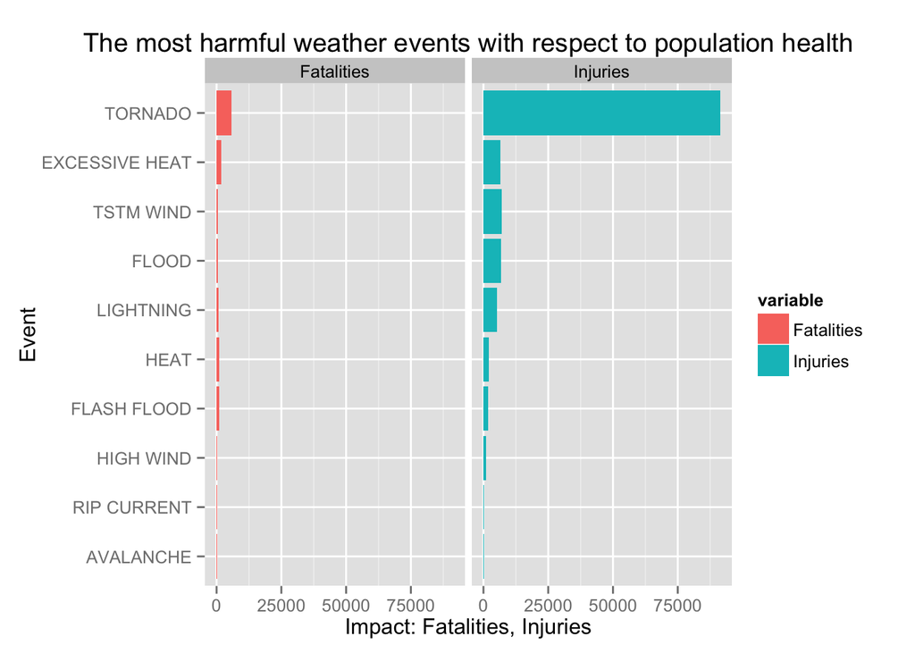

```r
library(ggplot2)
library(reshape2)

fat <- aggregate(cbind(Fatalities=csv$FATALITIES, Injuries=csv$INJURIES), by=list(Event=csv$EVTYPE), FUN=sum)

# Remove those that didn't had any impact
fat <- fat[fat$Fatalities != 0 | fat$Injuries != 0,]

# Order them by fatalities, injuries
fat <- fat[order(fat$Fatalities, fat$Injuries, decreasing=TRUE),]
fat <- fat[1:10,]
fat <- melt(fat[,c('Event', 'Fatalities', 'Injuries')], id.vars=1)

# plot
g <- ggplot(fat)
g <- g + geom_bar(stat="identity", aes(x=reorder(Event, value), y=value, fill=variable), position="dodge")
g <- g + coord_flip()
g <- g + facet_grid(. ~ variable)
g <- g + xlab("Event")
g <- g + ylab("Impact: Fatalities, Injuries")
g <- g + ggtitle("The most harmful weather events with respect to population health")
print(g)
```

The first ten events ordered by their impact are shown on the plot. Tornadoes are by far the worst event considering the high number of injuries and fatalities.

## Economic impact

We want to study the economic impact of the weather events.

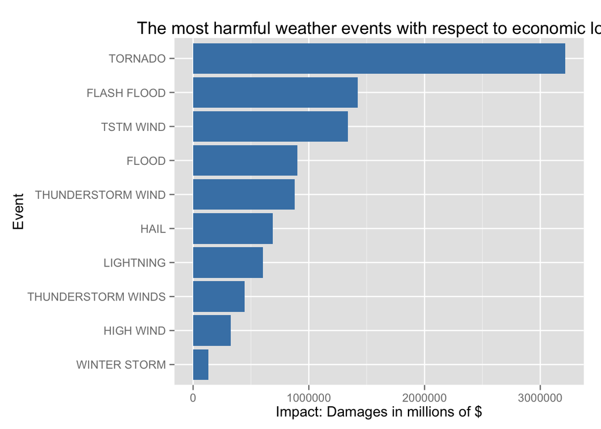

```r
options("scipen"=100, "digits"=4)
# Select the fields with K $
eco <- csv[csv$PROPDMGEXP == "K",]
# and aggregate them by EVTYPE
eco1 <- aggregate(csv$PROPDMG, by=list(Event=csv$EVTYPE), FUN=sum)
# Do the same for M $
eco <- csv[csv$PRODDMGEXP == "M"]
eco2 <- aggregate(csv$PROPDMG, by=list(Event=csv$EVTYPE), FUN=sum)

# Merge them together
newnum = eco1$x / 1000 + eco2$x
# ... and place the new number in eco1, we'll use eco1 from now
eco1$x <- newnum
eco1 <- eco1[eco1$x != 0,]
eco1 <- eco1[order(eco1$x, decreasing=TRUE),]
# Retain the first 10
eco1 <- eco1[1:10,]

g <- ggplot(eco1)
g <- g + geom_bar(stat="identity", aes(x=reorder(Event, x), y=x), position="dodge", fill="steelblue")
g <- g + coord_flip()
g <- g + xlab("Event")
g <- g + ylab("Impact: Damages in millions of $")
g <- g + ggtitle("The most harmful weather events with respect to economic loss")
print(g)
```

# Results

Tornadoes are the most devastating weather events. They are causing a high number of human casualties and extremely high economic losses. Until now they’ve caused the loss of 3000000 million of $. 5633 people died and 91346 were injured during the tornadoes.

Of course there are other weather events that have a high impact as well: Flood, Lightning, Wind. A curious thing is that there are some events who are causing high losses of humman lives or are causing injuries but they have a small or non-existent economic impact. Events involving heat can be seen in the top 10 list with harmful events for people but they are not on the top 10 list of weather events with economic impact.